# Explaining Song Popularity

STAT 420, Summer 2023, UIUC - Final Data Project

Soumya Nanda, Jonas Jansen, Noam Isachar

# Introduction

In this analysis project we decided to work on the [Spotify_1Million_Tracks](https://www.kaggle.com/datasets/amitanshjoshi/spotify-1million-tracks) which has popularity and other songs features and measures gathered by Spotify about over 1 Million tracks. Our main goal is to discover what makes a song popular and what impact different characteristics of a songs have on the song’s popularity. The model we will build will also be able to predict a song’s popularity.

The dataset is published and available on Kaggle and the data was extracted from the Spotify API using the Python library Spotipy. It contains information about over a Million songs from over 60,000 artists and across 82 genres between 2000 and 2023. The dataset also contains some interesting categorical variables which are some facts about each song such as the key (A, C, G#…), the mode (Major or Minor) and the time signature. In addition to those, there are numerical features about each songs which are computed by Spotify algorithms. To name a few, we have the danceability of the song, the energy, the acousticness and the valence, all in the range of 0.0 to 1.0.

Having all this musically detailed and in-depth information about so many songs provides the opportunity to use a linear model for researching what features of a song contribute to it’s chance of being popular, how a song should ideally be for it to be popular, and verify the possibility of predicting how popular a song is. Knowing all the above can drive certain decisions and directions when writing a song with the goal of achieving popularity.

# Methods

We start by importing the required libraries.

```r
library(knitr)
library(ggplot2)
library(GGally)
library(MASS)
library(gridExtra)
library(preprocessCore)
library(lmtest)
library(faraway)
```

Let’s have the first glance of the data.

```r
data = read.csv("../data/spotify_data.csv")
str(data)
```

```
## 'data.frame':    1159764 obs. of  20 variables:
##  $ X               : int  0 1 2 3 4 5 6 7 8 9 ...
##  $ artist_name     : chr  "Jason Mraz" "Jason Mraz" "Joshua Hyslop" "Boyce Avenue" ...
##  $ track_name      : chr  "I Won't Give Up" "93 Million Miles" "Do Not Let Me Go" "Fast Car" ...
##  $ track_id        : chr  "53QF56cjZA9RTuuMZDrSA6" "1s8tP3jP4GZcyHDsjvw218" "7BRCa8MPiyuvr2VU3O9W0F" "63wsZUhUZLlh1OsyrZq7sz" ...
##  $ popularity      : int  68 50 57 58 54 48 48 45 44 58 ...
##  $ year            : int  2012 2012 2012 2012 2012 2012 2012 2012 2012 2012 ...
##  $ genre           : chr  "acoustic" "acoustic" "acoustic" "acoustic" ...
##  $ danceability    : num  0.483 0.572 0.409 0.392 0.43 0.566 0.575 0.586 0.65 0.619 ...
##  $ energy          : num  0.303 0.454 0.234 0.251 0.791 0.57 0.606 0.423 0.628 0.28 ...
##  $ key             : int  4 3 3 10 6 2 9 7 7 8 ...
##  $ loudness        : num  -10.06 -10.29 -13.71 -9.85 -5.42 ...
##  $ mode            : int  1 1 1 1 0 1 1 1 1 0 ...
##  $ speechiness     : num  0.0429 0.0258 0.0323 0.0363 0.0302 0.0329 0.03 0.0261 0.0232 0.0317 ...
##  $ acousticness    : num  0.694 0.477 0.338 0.807 0.0726 0.688 0.0119 0.252 0.0483 0.73 ...
##  $ instrumentalness: num  0.00 1.37e-05 5.00e-05 0.00 1.93e-02 1.73e-06 0.00 5.83e-06 0.00 0.00 ...
##  $ liveness        : num  0.115 0.0974 0.0895 0.0797 0.11 0.0943 0.0675 0.0976 0.119 0.103 ...
##  $ valence         : num  0.139 0.515 0.145 0.508 0.217 0.96 0.364 0.318 0.7 0.292 ...
##  $ tempo           : num  133 140 140 205 172 ...
##  $ duration_ms     : int  240166 216387 158960 304293 244320 166240 152307 232373 235080 250063 ...
##  $ time_signature  : int  3 4 4 4 4 4 4 4 4 4 ...
```

## Data Preprocessing

We can get rid of the first column which is the index and also of the “track_id” column which is useless to us. For clarity, let’s change the values of “mode” from 0 and 1 to “minor” and “major” and replace the duration from milliseconds to minutes. Finally, we can create factor variables out of some of the columns.

```r
data$mode = ifelse(data$mode == 1, "major", "minor")
data$duration_m = data$duration_ms / 1000 / 60

data$year = factor(data$year)
data$genre = factor(data$genre)
data$key = factor(data$key)
data$mode = factor(data$mode)
data$time_signature = factor(data$time_signature)

data = subset(data, select = -c(X, track_id, duration_ms))

str(data)
```

```
## 'data.frame':    1159764 obs. of  18 variables:
##  $ artist_name     : chr  "Jason Mraz" "Jason Mraz" "Joshua Hyslop" "Boyce Avenue" ...
##  $ track_name      : chr  "I Won't Give Up" "93 Million Miles" "Do Not Let Me Go" "Fast Car" ...
##  $ popularity      : int  68 50 57 58 54 48 48 45 44 58 ...
##  $ year            : Factor w/ 24 levels "2000","2001",..: 13 13 13 13 13 13 13 13 13 13 ...
##  $ genre           : Factor w/ 82 levels "acoustic","afrobeat",..: 1 1 1 1 1 1 1 1 1 1 ...
##  $ danceability    : num  0.483 0.572 0.409 0.392 0.43 0.566 0.575 0.586 0.65 0.619 ...
##  $ energy          : num  0.303 0.454 0.234 0.251 0.791 0.57 0.606 0.423 0.628 0.28 ...
##  $ key             : Factor w/ 12 levels "0","1","2","3",..: 5 4 4 11 7 3 10 8 8 9 ...
##  $ loudness        : num  -10.06 -10.29 -13.71 -9.85 -5.42 ...
##  $ mode            : Factor w/ 2 levels "major","minor": 1 1 1 1 2 1 1 1 1 2 ...
##  $ speechiness     : num  0.0429 0.0258 0.0323 0.0363 0.0302 0.0329 0.03 0.0261 0.0232 0.0317 ...
##  $ acousticness    : num  0.694 0.477 0.338 0.807 0.0726 0.688 0.0119 0.252 0.0483 0.73 ...
##  $ instrumentalness: num  0.00 1.37e-05 5.00e-05 0.00 1.93e-02 1.73e-06 0.00 5.83e-06 0.00 0.00 ...
##  $ liveness        : num  0.115 0.0974 0.0895 0.0797 0.11 0.0943 0.0675 0.0976 0.119 0.103 ...
##  $ valence         : num  0.139 0.515 0.145 0.508 0.217 0.96 0.364 0.318 0.7 0.292 ...
##  $ tempo           : num  133 140 140 205 172 ...
##  $ time_signature  : Factor w/ 5 levels "0","1","3","4",..: 3 4 4 4 4 4 4 4 4 4 ...
##  $ duration_m      : num  4 3.61 2.65 5.07 4.07 ...
```

Looks good. The dataset now 18 variables, two of which are the artist name and track name which we won’t use in the model but only for exploration and interpretation. That leaves us with the “popularity” variable which we are going to use as the response and 15 other variables that can help us as predictors. 10 of which are numeric and 5 are categorical factor variables.

Now let’s check for null values.

```r
colSums(is.na(data))
```

```
##      artist_name       track_name       popularity             year
##                0                0                0                0
##            genre     danceability           energy              key
##                0                0                0                0
##         loudness             mode      speechiness     acousticness
##                0                0                0                0
## instrumentalness         liveness          valence            tempo
##                0                0                0                0
##   time_signature       duration_m
##                0                0
```

There are none.

## Data Exploration and Analysis

### Data Description

We can now look at the summary of the data which shows statistics of the different variables.

```r
summary(data)
```

```
##  artist_name         track_name          popularity         year
##  Length:1159764     Length:1159764     Min.   :  0.0   2018   : 56572
##  Class :character   Class :character   1st Qu.:  5.0   2017   : 56241
##  Mode  :character   Mode  :character   Median : 15.0   2019   : 55793
##                                        Mean   : 18.4   2020   : 55066
##                                        3rd Qu.: 29.0   2012   : 54797
##                                        Max.   :100.0   2022   : 53692
##                                                        (Other):827603
##          genre          danceability       energy           key
##  black-metal:  21852   Min.   :0.000   Min.   :0.000   7      :139635
##  gospel     :  21621   1st Qu.:0.413   1st Qu.:0.454   0      :130081
##  ambient    :  21389   Median :0.550   Median :0.694   2      :123690
##  acoustic   :  21097   Mean   :0.537   Mean   :0.640   9      :119293
##  alt-rock   :  20918   3rd Qu.:0.677   3rd Qu.:0.873   1      :112806
##  emo        :  20845   Max.   :0.993   Max.   :1.000   5      : 94032
##  (Other)    :1032042                                   (Other):440227
##     loudness         mode         speechiness      acousticness
##  Min.   :-58.10   major:736048   Min.   :0.0000   Min.   :0.0000
##  1st Qu.:-10.83   minor:423716   1st Qu.:0.0371   1st Qu.:0.0064
##  Median : -7.45                  Median :0.0507   Median :0.1470
##  Mean   : -8.98                  Mean   :0.0928   Mean   :0.3215
##  3rd Qu.: -5.28                  3rd Qu.:0.0890   3rd Qu.:0.6400
##  Max.   :  6.17                  Max.   :0.9710   Max.   :0.9960
##
##  instrumentalness    liveness         valence          tempo
##  Min.   :0.0000   Min.   :0.0000   Min.   :0.000   Min.   :  0.0
##  1st Qu.:0.0000   1st Qu.:0.0979   1st Qu.:0.226   1st Qu.: 98.8
##  Median :0.0018   Median :0.1340   Median :0.438   Median :121.9
##  Mean   :0.2523   Mean   :0.2230   Mean   :0.456   Mean   :121.4
##  3rd Qu.:0.6140   3rd Qu.:0.2920   3rd Qu.:0.674   3rd Qu.:139.9
##  Max.   :1.0000   Max.   :1.0000   Max.   :1.000   Max.   :250.0
##
##  time_signature   duration_m
##  0:   1228      Min.   :  0.03
##  1:  12660      1st Qu.:  3.02
##  3: 112332      Median :  3.76
##  4:1010673      Mean   :  4.16
##  5:  22871      3rd Qu.:  4.78
##                 Max.   :100.01
##
```

Let’s explain the variables we have here. Our goal is to explain and predict the “popularity” variable, which is calculated by an algorithm of Spotify, and according to them it “is based, in the most part, on the total number of plays the track has had and how recent those plays are”.

Besides the artist and track name and the year and genre which are obvious, we have some more factual categorical variables:

1. Key: ranges from 0 to 11 and indicates the key the track is in starting from 0 = C.
2. Mode: refers to whether the track is in major or minor scale.
3. Time signature: An estimated time signature which specifies how many beats are in a bar.

The numerical variables mostly contain audio features of the track:

1. Danceability: Danceability describes how suitable a track is for dancing based on a combination of musical elements including tempo, rhythm stability, beat strength, and overall regularity.
2. Energy: Energy is a measure from 0.0 to 1.0 and represents a perceptual measure of intensity and activity. Typically, energetic tracks feel fast, loud, and noisy.
3. Loudness: The overall loudness of a track in decibels (dB).
4. Speechiness: Speechiness detects the presence of spoken words in a track.
5. Acousticness: A confidence measure from 0.0 to 1.0 of whether the track is acoustic.
6. Instrumentalness: Predicts whether a track contains no vocals. “Ooh” and “aah” sounds are treated as instrumental in this context.
7. Liveness: Detects the presence of an audience in the recording.
8. Valence: A measure from 0.0 to 1.0 describing the musical positiveness conveyed by a track. Tracks with high valence sound more positive (e.g. happy, cheerful, euphoric), while tracks with low valence sound more negative (e.g. sad, depressed, angry).
9. Tempo: The overall estimated tempo of a track in beats per minute (BPM).
10. Duration: The duration of the track in minutes.

More on the variables can be read on the [Spotify API documentation](https://developer.spotify.com/documentation/web-api).

The data looks clean but there is one case of outliers in the duration of tracks. Let’s keep track with maximum length of 40 minutes, which is by itself very unusual but we can still think of some songs of that length (The Orb - The Blue Room). In fact, any track longer than 40 minutes has to be considered as an album by the British Phonographic Industry. In addition, it is safe to say that the maximum duration of 100 minutes is not something we want to base our model on as it doesn’t realistically reflect real songs.

```r
data = data[data$duration_m <= 40, ]
```

One other thing we want to verify is the 0 values n tempo.

```r
head(data[data$tempo == 0, 1:2], 10)
```

```
##                      artist_name
## 3719                 Yellow Eyes
## 9178            Benjamin Britten
## 10558 Papa Razzi and the Photogs
## 21278                    Bahamas
## 27316               Napalm Death
## 27342             Insect Warfare
## 27720                   Dropdead
## 27748                      Bingo
## 27754                 Painkiller
## 27755                    Wormrot
##                                                     track_name
## 3719                                                 Cathedral
## 9178  Gloriana, Op. 53: Choral Dances: No. 3. Time and Concord
## 10558        Jeremy Renner, You Are a Good Actor, Yes You Are!
## 21278                                            Any Other Way
## 27316                                         Your Achievement
## 27342                                           Street Sweeper
## 27720                                        End The Slaughter
## 27748                                                Välkommen
## 27754                                              Trailmarker
## 27755                      You Suffer But Why Is It My Problem
```

After listening to some of those we can verify that the 0 for tempo are legit values and these songs don’t follow a beat.

Another suspicious 0 is for the popularity. Knowing Spotify, there is a lot of junk there that can’t really be tagged as songs and it is possible that it ended up in this dataset and it is contaminating the data. Another possibility is that it is a bug in the dataset, since getting zero popularity and not even a fraction above it means that no streams were made. Let’s see some of the tracks with zero popularity and manually verify what happened.

```r
head(data[data$popularity == 0, 1:2], 10)
```

```
##                   artist_name                      track_name
## 1345            Joni Haastrup                       Greetings
## 1349        Sir Victor Uwaifo                      Do amen do
## 1350   Kaleta & Zozo Afrobeat                      Shit Music
## 1351   Kaleta & Zozo Afrobeat                          Mugabe
## 1354                    Fanga                          Kononi
## 1355      Music Is the Weapon      Riva Ett Får (Bonus Track)
## 1356 Chicago Afrobeat Project Colonial Waiting Room Mentality
## 1357 Ariya Astrobeat Arkestra      Future Ancestors - 7" Edit
## 1362             Euforquestra        Intro to Ochun/Ochun Dub
## 1363      Music Is the Weapon                     Upside Down
```

After carefully checking examples, we noticed some of them have Millions of streams, like Greetings by Joni Haastrup. This makes us think that there is a problem and some songs are added with zero popularity by mistake. Let’s see how many songs have zero popularity, and how many have any other number.

```r
print(paste("Number of tracks with zero popularity:", nrow(data[data$popularity == 0, ])))
```

```
## [1] "Number of tracks with zero popularity: 158170"
```

```r
print(paste("Number of tracks with non-zero popularity:", nrow(data[data$popularity > 0, ])))
```

```
## [1] "Number of tracks with non-zero popularity: 1000883"
```

For some reason tracks with zero popularity are over 10% of the dataset, which other than being suspicious is also VERY unbalanced. We decide to remove these observations as there seems to be too many of them, and also in some cases that the value doesn’t make sense.

```r
data = data[data$popularity > 0, ]
summary(data)
```

```
##  artist_name         track_name          popularity         year
##  Length:1000883     Length:1000883     Min.   :  1.0   2019   : 52666
##  Class :character   Class :character   1st Qu.:  9.0   2018   : 52509
##  Mode  :character   Mode  :character   Median : 18.0   2017   : 51885
##                                        Mean   : 21.3   2020   : 51792
##                                        3rd Qu.: 31.0   2022   : 51533
##                                        Max.   :100.0   2021   : 50862
##                                                        (Other):689636
##          genre         danceability       energy           key
##  gospel     : 21564   Min.   :0.000   Min.   :0.000   7      :118942
##  alt-rock   : 20793   1st Qu.:0.414   1st Qu.:0.461   0      :112930
##  emo        : 20054   Median :0.549   Median :0.697   2      :106287
##  ambient    : 20015   Mean   :0.536   Mean   :0.643   9      :102672
##  black-metal: 19822   3rd Qu.:0.674   3rd Qu.:0.873   1      : 97518
##  k-pop      : 19651   Max.   :0.993   Max.   :1.000   5      : 81701
##  (Other)    :878984                                   (Other):380833
##     loudness         mode         speechiness      acousticness
##  Min.   :-58.10   major:635485   Min.   :0.0000   Min.   :0.0000
##  1st Qu.:-10.57   minor:365398   1st Qu.:0.0367   1st Qu.:0.0071
##  Median : -7.29                  Median :0.0500   Median :0.1460
##  Mean   : -8.83                  Mean   :0.0934   Mean   :0.3153
##  3rd Qu.: -5.19                  3rd Qu.:0.0889   3rd Qu.:0.6180
##  Max.   :  6.17                  Max.   :0.9700   Max.   :0.9960
##
##  instrumentalness    liveness         valence          tempo
##  Min.   :0.0000   Min.   :0.0000   Min.   :0.000   Min.   :  0.0
##  1st Qu.:0.0000   1st Qu.:0.0984   1st Qu.:0.225   1st Qu.: 98.2
##  Median :0.0012   Median :0.1340   Median :0.433   Median :121.1
##  Mean   :0.2407   Mean   :0.2241   Mean   :0.452   Mean   :121.5
##  3rd Qu.:0.5510   3rd Qu.:0.2920   3rd Qu.:0.668   3rd Qu.:140.0
##  Max.   :1.0000   Max.   :1.0000   Max.   :1.000   Max.   :249.8
##
##  time_signature   duration_m
##  0:   784       Min.   : 0.09
##  1: 10288       1st Qu.: 3.03
##  3: 95472       Median : 3.74
##  4:875348       Mean   : 4.07
##  5: 18991       3rd Qu.: 4.69
##                 Max.   :39.97
##
```

### Numerical Variables Analysis

Let’s start exploring the numerical variables and the relationships between them.

```r
num_vars = sapply(data, is.numeric)
num_data = data[, num_vars]
num_data_sample = num_data[sample(nrow(num_data), 10000), ]

pair_plot_sample = ggpairs(num_data_sample, upper = list(continuous = wrap("cor", size = 6))) +
  theme_bw() +
  theme(axis.line=element_blank(),
        axis.text=element_blank(),
        axis.ticks=element_blank(),
        text = element_text(size = 30))
```

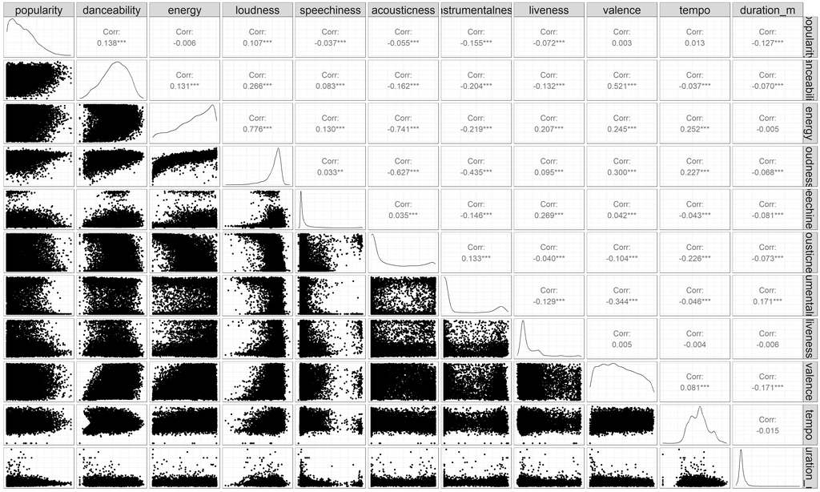

```r
print(pair_plot_sample, progress = F)
```

We sampled 10,000 observations from the dataset for this pair-plot since doing it on the entire dataset would take much more time and also flood the plots with so much dots that they would become all black. A sample of 10,000 is more than enough to show the relationship between variables.

After getting the hint that transformations are required, let’s run the Box-Cox method on every non-negative numerical variable to see which is the recommended transformation.

```r
eps = 1e-8
# Function to calculate the optimal lambda for a variable using Box-Cox
get_optimal_lambda = function(variable) {
  lm_formula = as.formula(paste(variable, "+ eps ~ 1"))
  result = boxcox(lm_formula, data = data, plot=FALSE)
  return(result$x[which.max(result$y)])  # Return the optimal lambda
}

# Create an empty data frame to store the results
table_optimal_lambdas = data.frame(variable = character(), optimal_lambda = numeric(), stringsAsFactors = FALSE)

# Use a loop to get the optimal lambda for each variable
for (var in names(num_vars[num_vars])) {
  if (min(data[[var]]) < 0) {
    optimal_lambda = 1
  }
  else {
    optimal_lambda = get_optimal_lambda(var)
  }
  table_optimal_lambdas = rbind(table_optimal_lambdas, data.frame(variable = var, optimal_lambda = optimal_lambda))
}

# Print the table
print(table_optimal_lambdas)
```

```
##            variable optimal_lambda
## 1        popularity            0.4
## 2      danceability            1.1
## 3            energy            1.2
## 4          loudness            1.0
## 5       speechiness            0.1
## 6      acousticness            0.2
## 7  instrumentalness            0.0
## 8          liveness            0.0
## 9           valence            0.6
## 10            tempo            0.7
## 11       duration_m            0.1
```

Save the transformed variables with the recommended lambdas into a new dataframe. Then, we plot the pair-plot again and see of the distributions resemble a normal distribution.

```r
apply_boxcox_transformation = function(variable, lambda) {
  transformed_variable = if (abs(lambda) < 0.01) {
    log(data[[variable]] + eps)
  } else {
    (data[[variable]]^lambda - 1) / lambda
  }
  return(transformed_variable)
}

categorical_vars = names(data)[sapply(data, function(x) is.factor(x) || is.character(x))]

# Create a new data frame to store the transformed data
boxcox_data = data.frame(
  sapply(names(num_vars[num_vars]), function(var) apply_boxcox_transformation(var, table_optimal_lambdas[table_optimal_lambdas$variable == var, "optimal_lambda"])),
  data[categorical_vars],  # Add the categorical columns from the original data
  stringsAsFactors = FALSE
)
boxcox_data = boxcox_data[names(data)]
```

```r
boxcox_num_data = boxcox_data[, num_vars]
boxcox_num_data_sample = boxcox_num_data[sample(nrow(boxcox_num_data), 10000), ]

boxcox_pair_plot_sample = ggpairs(boxcox_num_data_sample, upper = list(continuous = wrap("cor", size = 6))) +
  theme_bw() +
  theme(axis.line=element_blank(),
        axis.text=element_blank(),
        axis.ticks=element_blank(),
        text = element_text(size = 30))
```

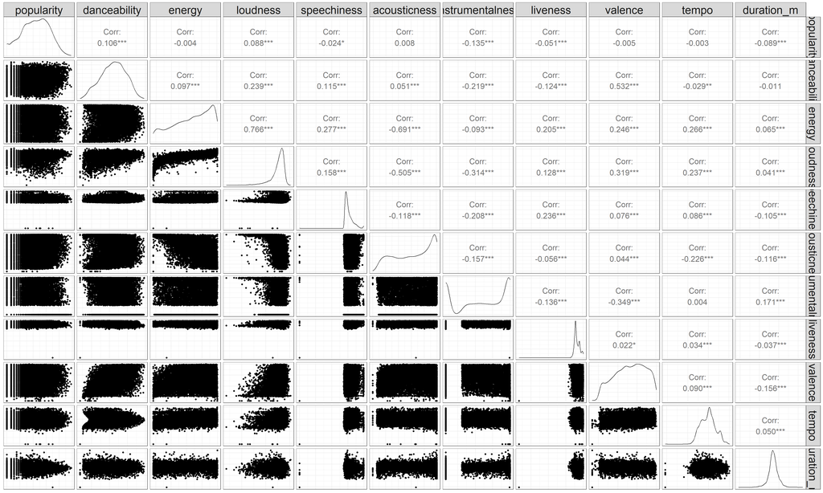

```r
print(boxcox_pair_plot_sample, progress = F)
```

The distributions still look off. When Box-Cox transformations are unsatisfactory, quantile normalization emerges as a robust alternative. Unlike Box-Cox, quantile normalization is distribution-free and aligns empirical distributions across variables, ensuring fair comparisons and improved statistical analyses, even with non-normally distributed data. It provides a versatile, data-driven approach to normalize variables, making it an effective choice when dealing with datasets lacking a specific theoretical distribution.

Quantile normalization equalizes the empirical distributions of numerical data across variables by mapping each value to its corresponding quantile in a reference distribution (e.g., uniform or Gaussian). This process ensures that all variables share the same distributional properties, making the data suitable for statistical analyses and comparisons without relying on any specific theoretical distribution.

Let’s perform quantile normalization on the numerical variables and the show the pair-plot again.

```r
quantile_data = as.data.frame(normalize.quantiles(as.matrix(num_data)))
colnames(quantile_data) = colnames(num_data)
quantile_data = cbind(quantile_data, data[categorical_vars])
quantile_data = quantile_data[names(data)]
```

```r
quantile_num_data = quantile_data[, num_vars]
quantile_num_data_sample = quantile_num_data[sample(nrow(quantile_num_data), 10000), ]

quantile_pair_plot_sample = ggpairs(quantile_num_data_sample, upper = list(continuous = wrap("cor", size = 6))) +
  theme_bw() +
  theme(axis.line=element_blank(),
        axis.text=element_blank(),
        axis.ticks=element_blank(),
        text = element_text(size = 30))
```

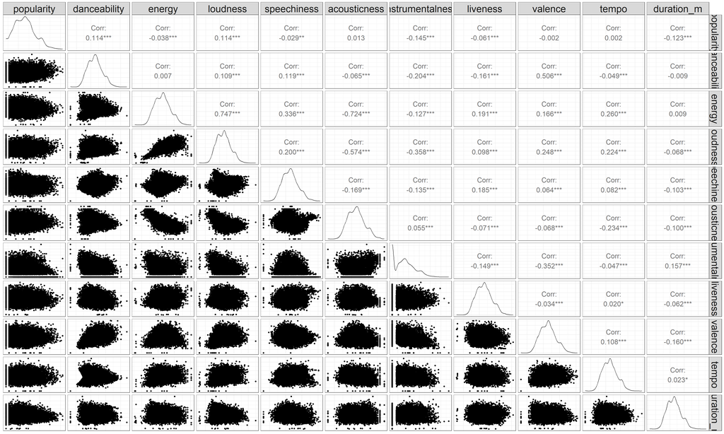

```r
print(quantile_pair_plot_sample, progress = F)
```

One more interesting analysis to try is to bin the popularity into 10 chunks and see the difference in each variable across the different bins of popularity.

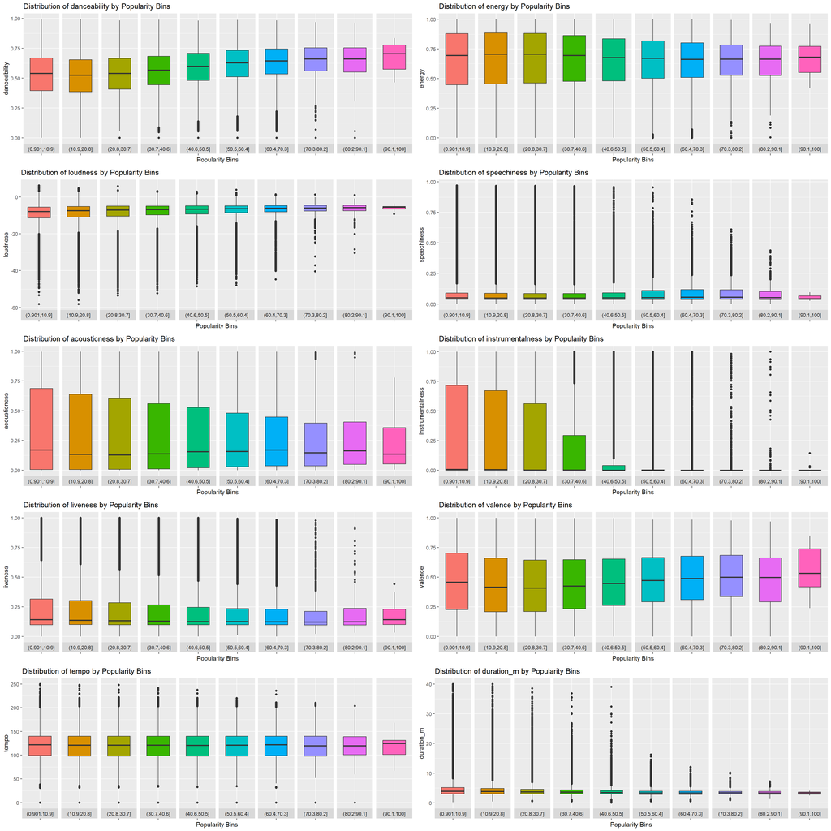

```r
data$popularity_bins = cut(data$popularity, breaks = 10)
plot_list = list()

for (column in names(data)) {
  if (column != "popularity_bins" && column != "popularity" && num_vars[column]) {
    plot = ggplot(data, aes(x = popularity_bins, y = .data[[column]], fill = popularity_bins)) +
      geom_boxplot() +
      labs(x = "Popularity Bins", y = column, title = paste("Distribution of", column, "by Popularity Bins")) +
      theme(axis.text.x = element_blank(), legend.position = "none") +
      facet_grid(~ popularity_bins, scales = "free_x", space = "free_x", switch = "x")

    plot_list[[column]] = plot
  }
}

grid.arrange(grobs = plot_list, ncol = 2)
```

```r
data = subset(data, select = -c(popularity_bins))
```

From the plots above we can see that across all the numerical predictors we have less variance and outliers as the popularity grows. They all stabilize around some range in the higher bins. This is worrying in terms of the constant variance assumption, but we hope the transformations will help mitigate that.

We can see a weak positive trend in the danceability, which resembles the one of the valence. This means that the popular songs tend to be happier and more danceable.

Also the energy and loudness share a similar behavior between them, but the loudness has much less variance. Anyway both of them don’t seem to have an observable relationship with the popularity.

As for the tempo, its mean is pretty stable across all the bins, but the chance for outliers on both sides are decreasing as the popularity increases. Maybe a polynomial transformation will work here?

Finally, the chance of a long song to be popular is very low as most of the longer songs are in the lower half of the popularity bins.

### Categorical Variables Analysis

Now let’s take a look at the impact of the categorical predictors. We start with the genre, and since it has many values and plotting would be difficult, what we can do is check the genres with the best and worst mean popularity.

```r
mean_popularity_by_genre = aggregate(popularity ~ genre, data, mean)

best_mean_popularity_by_genre = mean_popularity_by_genre[order(-mean_popularity_by_genre$popularity), ]
worst_mean_popularity_by_genre = mean_popularity_by_genre[order(mean_popularity_by_genre$popularity), ]
```

```r
print(head(best_mean_popularity_by_genre, 10))
```

```
##        genre popularity
## 57       pop      56.06
## 64      rock      47.52
## 43   hip-hop      46.56
## 15     dance      43.25
## 50     metal      39.80
## 3   alt-rock      38.83
## 67       sad      36.56
## 46 indie-pop      35.69
## 28      folk      33.67
## 14   country      33.14
```

```r
print(head(worst_mean_popularity_by_genre, 10))
```

```
##             genre popularity
## 66        romance      3.991
## 36      grindcore      5.150
## 79          tango      5.845
## 19 detroit-techno      6.115
## 23        dubstep      6.890
## 59      power-pop      7.097
## 9   chicago-house      7.165
## 42    heavy-metal      8.341
## 7       breakbeat      8.803
## 82       trip-hop      8.934
```

As expected, the genre greatly impacts the popularity. There is a huge difference in the mean popularity across genres.

The only issue with the genre is that there are two many of them, with 82 values. That could be a problem if we decide to interact it with some other variables, which could happen since different genres might have different recipes for success. What we can do is create another variable called “upper_genre” which will be a mapping of the current genres to a higher level genre. We will create the mapping ourselves by carefully listening, researching and examining the current genres and categorizing them into upper genres. We will use the upper genre with caution.

```r
genre_mapping = list(
  "rock" = c("alt-rock", "garage", "hard-rock", "psych-rock", "rock", "rock-n-roll"),
  "metal" = c("black-metal", "death-metal", "emo", "goth", "grindcore", "hardcore", "metal", "metalcore", "heavy-metal"),
  "electronic" = c("ambient", "breakbeat", "chicago-house", "dance", "dancehall", "deep-house", "detroit-techno",
                   "drum-and-bass", "dub", "dubstep", "edm", "electro", "electronic", "hardstyle", "house",
                   "minimal-techno", "progressive-house", "techno", "trance", "party", "chill", "club", "industrial"),
  "pop" = c("cantopop", "indie-pop", "k-pop", "pop", "power-pop", "pop-film"),
  "country" = "country",
  "folk" = "folk",
  "classical/opera" = c("classical", "opera"),
  "hip-hop" = "hip-hop",
  "blues" = "blues",
  "jazz" = "jazz",
  "soul" = "soul",
  "world" = c("indian", "spanish", "swedish", "tango", "forro", "sertanejo", "salsa", "samba", "french", "german", "afrobeat"),
  "ska" = "ska",
  "punk" = c("punk", "punk-rock"),
  "funk/disco" = c("funk", "disco"),
  "trip-hop" = "trip-hop",
  "acoustic" = c("acoustic", "singer-songwriter", "songwriter", "sad", "guitar", "piano"),
  "new-age" = "new-age",
  "other" = c("comedy", "gospel", "romance", "show-tunes", "sleep", "groove")
)

map_genre = function(genre) {
  for (key in names(genre_mapping)) {
    if (genre %in% unlist(genre_mapping[[key]])) {
      return(key)
    }
  }
}

data$upper_genre = sapply(data$genre, map_genre)
quantile_data$upper_genre = data$upper_genre
```

While handling and categorizing the genres we noticed some inconsistencies with the genre values across different songs. Some completely unrelated songs were wrongly categorized to the same genre, which makes sense since the genre is an algorithm-based variable so errors can happen. This leads us to think that we want to try a model without considering the genre, not even in the reduced form. Before proceeding let’s see the average popularity of the new upper genres.

```r
mean_popularity_by_upper_genre = aggregate(popularity ~ upper_genre, data, mean)

best_mean_popularity_by_upper_genre = mean_popularity_by_upper_genre[order(-mean_popularity_by_upper_genre$popularity), ]
worst_mean_popularity_by_upper_genre = mean_popularity_by_upper_genre[order(mean_popularity_by_upper_genre$popularity), ]
```

```r
print(head(best_mean_popularity_by_upper_genre, 10))
```

```
##    upper_genre popularity
## 8      hip-hop      46.56
## 6         folk      33.67
## 4      country      33.14
## 9         jazz      30.70
## 17        soul      30.68
## 14        punk      25.09
## 13         pop      24.72
## 15        rock      23.52
## 7   funk/disco      22.37
## 2        blues      21.71
```

```r
print(head(worst_mean_popularity_by_upper_genre, 10))
```

```
##        upper_genre popularity
## 18        trip-hop      8.934
## 11         new-age     12.324
## 16             ska     14.986
## 12           other     16.118
## 10           metal     18.640
## 19           world     18.871
## 1         acoustic     20.403
## 3  classical/opera     20.447
## 5       electronic     20.989
## 2            blues     21.706
```

Now we can look at the year variable.

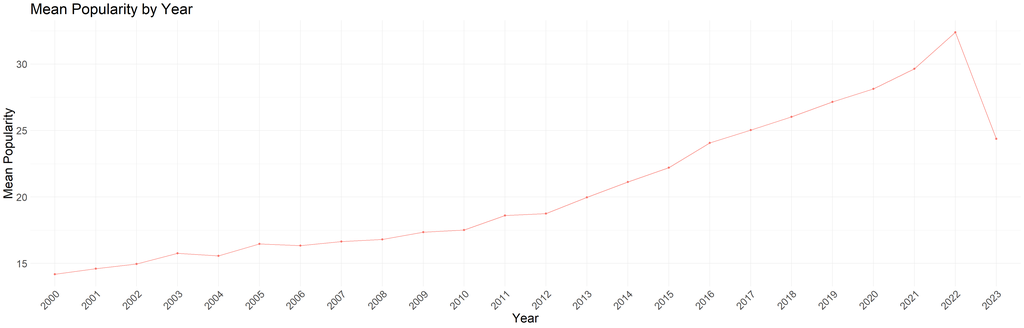

```r
mean_popularity_by_year = aggregate(data$popularity, by = list(year = data$year), mean)
mean_popularity_by_year = reshape2::melt(mean_popularity_by_year, id.vars = "year")

ggplot(mean_popularity_by_year, aes(x = year, y = value, group = variable, color = variable)) +
  geom_line() +
  geom_point() +
  labs(x = "Year", y = "Mean Popularity", title = "Mean Popularity by Year") +
  theme_minimal() +
  theme(axis.text.x = element_text(angle = 45, hjust = 1),
        text = element_text(size = 22)) +
  theme(legend.position = "none")
```

Since the popularity is based also on whether the track was recently played, we see greater popularity to recent songs which makes sense. However, our main goal is to understand what elements of a song have impact on making it popular, and when writing a song it is not possible to change the year it is released in. In other words, the year is not going to help us say what makes a song popular since the popularity is biased towards recent songs and the time is not something an artist controls.

In order to be able to explain the model but also utilize the year in our predictions, we will use the year variable to interact with all the other variables, and then we can select each year and see how the parameters of the other variables change. For example, by interacting the year with the rest we will be able to select the year 2023 and see how a song should be in order to maximize its chances of popularity in 2023.

Despite all that, we are still curious to see the variation in the characteristics of songs across different years, and see what features of songs from different years contribute to its popularity right now. Let’s see the mean of each variable as a function of the year.

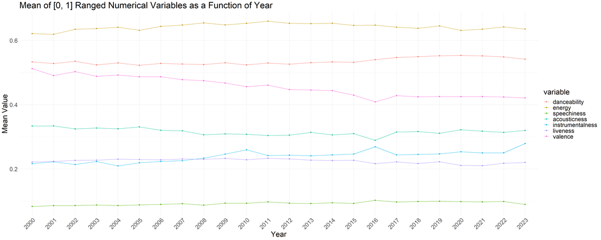

```r
mean_data = aggregate(data[, num_vars], by = list(year = data$year), mean)
mean_data = subset(mean_data, select = -c(popularity, tempo, duration_m, loudness))
mean_melted = reshape2::melt(mean_data, id.vars = "year")

ggplot(mean_melted, aes(x = year, y = value, group = variable, color = variable)) +
  geom_line() +
  geom_point() +
  labs(x = "Year", y = "Mean Value",
       title = "Mean of [0, 1] Ranged Numerical Variables as a Function of Year") +
  theme_minimal() +
  theme(axis.text.x = element_text(angle = 45, hjust = 1),
        text = element_text(size = 22))
```

To our surprise, there are no significant trends in the means over the years. The only visible changes are the drop in the valence which generally means that songs became sadder, and the rise and fall of energy that reached a peak around 2010.

Let’s do the the same plot but for the correlation of each variable with the popularity over the years.

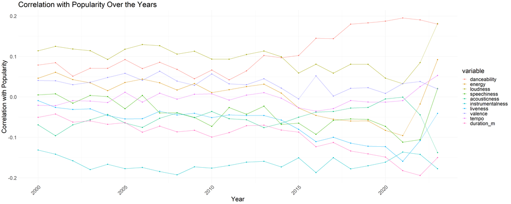

```r
cor_data = data.frame(year = unique(data$year))
cor_data$year = as.numeric(as.character(cor_data$year))

for (var in names(num_vars[num_vars])) {
  if (var != "popularity"){
    cor_values = sapply(unique(data$year), function(y) {
      subset_data = subset(data, as.numeric(as.character(year)) == y)
      cor(subset_data[[var]], subset_data$popularity)
    })

    cor_data[var] = cor_values
  }
}

cor_melted = reshape2::melt(cor_data, id.vars = "year")

ggplot(cor_melted, aes(x = year, y = value, group = variable, color = variable)) +
  geom_line() +
  geom_point() +
  labs(x = "Year", y = "Correlation with Popularity",
       title = "Correlation with Popularity Over the Years") +
  theme_minimal() +
  theme(axis.text.x = element_text(angle = 45, hjust = 1),
        text = element_text(size = 22))
```

In the correlations plot we see a clear rise in the impact danceability and energy have on the popularity, especially after 2020. Groovy energetic songs are becoming more and more likable. The duration went from 0.0 to almost -0.2 at some point, which highlights that popular songs are getting shorter.

We hope that after building and analyzing the final model we will have more meaningful insights.

Now let’s see how the time signature, key and mode affect the popularity.

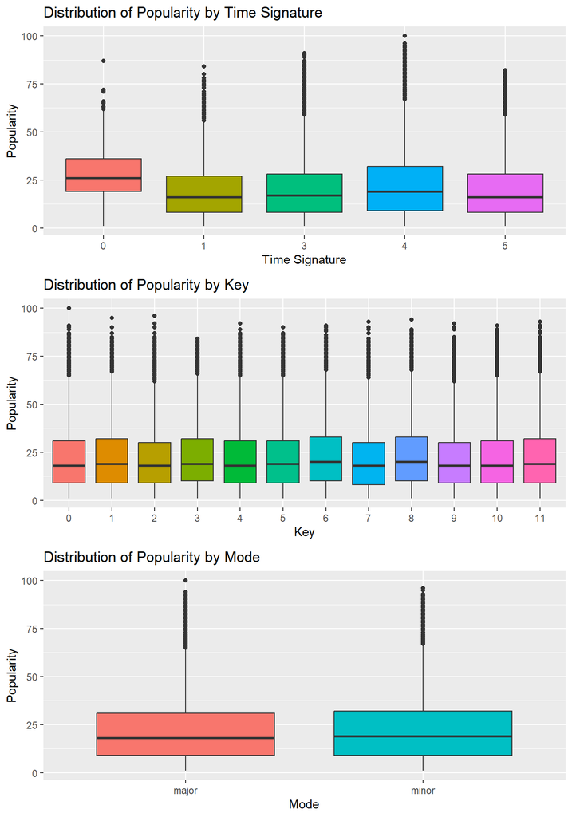

```r
ts_pop = ggplot(data, aes(x = time_signature, y = popularity, fill=time_signature)) +
  geom_boxplot() +
  theme(legend.position = "none") +
  labs(x = "Time Signature", y = "Popularity", title = "Distribution of Popularity by Time Signature")

key_pop = ggplot(data, aes(x = key, y = popularity, fill=key)) +
  geom_boxplot() +
  theme(legend.position = "none") +
  labs(x = "Key", y = "Popularity", title = "Distribution of Popularity by Key")

mode_pop = ggplot(data, aes(x = mode, y = popularity, fill=mode)) +
  geom_boxplot() +
  theme(legend.position = "none") +
  labs(x = "Mode", y = "Popularity", title = "Distribution of Popularity by Mode")

grid.arrange(ts_pop, key_pop, mode_pop, ncol = 1)
```

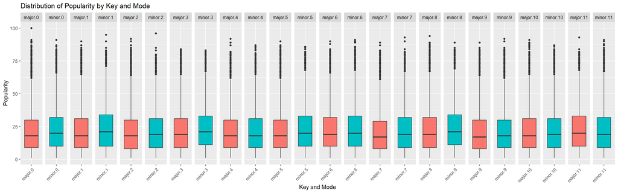

```r
data$key_mode_combination = interaction(data$mode, data$key)

combined_plot = ggplot(data, aes(x = key_mode_combination, y = popularity, fill = mode)) +
  geom_boxplot() +
  theme(legend.position = "none") +
  labs(x = "Key and Mode", y = "Popularity", title = "Distribution of Popularity by Key and Mode") +
  theme(axis.text.x = element_text(angle = 45, hjust = 1)) +
  facet_wrap(~ key_mode_combination, scales = "free_x", ncol = 24)

print(combined_plot)
```

```r
data = subset(data, select = -c(key_mode_combination))
```

Still doesn’t look significant for the popularity. In terms of the mean and even the outliers the boxplots don’t look too different.

There is little chance that we will need the time signature, key or mode in the final model.

### Conclusions

Now we can proceed and build some models.

## Model Building

### Define Test Criteria

Before we start fitting some models, we split the data into test and train data. This helps us evaluating the models, also towards overfitting. The chosen ratio is 70% train data and 30% test data. We do this for both the quantile transformed data and the original data set.

```r
set.seed(42)
ratio = 0.7

# normal data set
data_fit = subset(data, select = -c(artist_name, track_name))

sample_size = floor(ratio * nrow(data_fit))
data_idx = sample(nrow(data_fit), sample_size)
data_trn = data_fit[data_idx, ]
data_tst = data_fit[-data_idx, ]

# quantile normalized data set
quantile_data_fit = subset(quantile_data, select = -c(artist_name, track_name))

quantile_data_idx = sample(nrow(quantile_data_fit), sample_size)
quantile_data_trn = quantile_data_fit[quantile_data_idx,]
quantile_data_tst = quantile_data_fit[-quantile_data_idx, ]
```

To make the evaluation of the fitted models easier, we define a function which is calculating the most important tests for us. The function receives the model and the test dataset as parameters. The first test is the Shapiro-Wilk test of normality. Note that the shaprio.test function in R is limited to accept max. 5000 residuals. Since the original dataset contains 1 million tracks, these are too many residuals even after splitting the dataset into test and train. As a workaround, a random sample size of 5000 residuals is picked. This makes the result of that test somewhat unreliable, since it can get a biased sample. But the value should still give us an idea how good or bad the model might be.

Further test criteria are the Breusch-Pagan test for checking the constant variance assumption, loocv_rmse for cross validation the model and also RMSE and MAE calculated from the given test data. The models Adjusted R-Squared values are returned too.

```r
check_model = function(model, test_data){
  model_info = summary(model)
  set.seed(42)

  # sample for shapiro
  sample_idx = sample(length(resid(model)), 5000)
  residuals_sample = resid(model)[sample_idx]

  # shapiro
  shapiro_p_value =  shapiro.test(residuals_sample)$p.value

  # bp test
  bptest_p_value = bptest(model)$p.value

  # loocv_rmse
  loocv_rmse = sqrt(mean((resid(model) / (1 - hatvalues(model))) ^ 2))

  # rsme and mae using the test data
  predictions = predict(model, newdata = test_data)
  rsme_test = sqrt(mean((test_data$popularity - predictions)^2))
  mae_test = mean(abs(test_data$popularity - predictions))

  # Creating a data frame to store the results
  results = data.frame(
    adjusted_r_squared = model_info$adj.r.squared,
    rsme_test = rsme_test,
    mae_test = mae_test,
    loocv_rmse = loocv_rmse,
    shapiro = shapiro_p_value,
    bptest = bptest_p_value
  )

  results
}
```

Further a function for plotting the Fitted vs Residuals Plot and the Q-Q Plot is defined.

```r
plot_model = function(model) {
  # Fitted vs Residuals Plot
  plot(fitted(model), resid(model), col = "grey", pch = 20,
     xlab = "Fitted", ylab = "Residuals", main = "Fitted vs Residuals Plot")
  abline(h = 0, col = "darkorange", lwd = 2)

  # Q-Q Plot
  qqnorm(resid(model), main = "Q-Q Plot", col = "darkgrey")
  qqline(resid(model), col = "dodgerblue", lwd = 2)
}
```

### Full Additive Model

Now the data is prepared and the tests are defined. We can start fitting. The first model we build is a full additive one including all predictors. One exception is on the upper genre, since this should be a replacement for genre in a better explainable and useful model. And we choose the non transformed data set. This should give us a base to how much we need to do improving the model

```r
model_add_full = lm(popularity ~ . -upper_genre, data = data_trn)
```

Let’s run the tests and see how well the model performs.

```r
model_add_full_check = check_model(model_add_full, data_tst)
rownames(model_add_full_check) = c("Fully Additive No Transformations")
model_add_full_check
```

```
##                                   adjusted_r_squared rsme_test mae_test
## Fully Additive No Transformations             0.5273     10.42    8.088
##                                   loocv_rmse   shapiro bptest
## Fully Additive No Transformations      10.44 1.054e-31      0
```

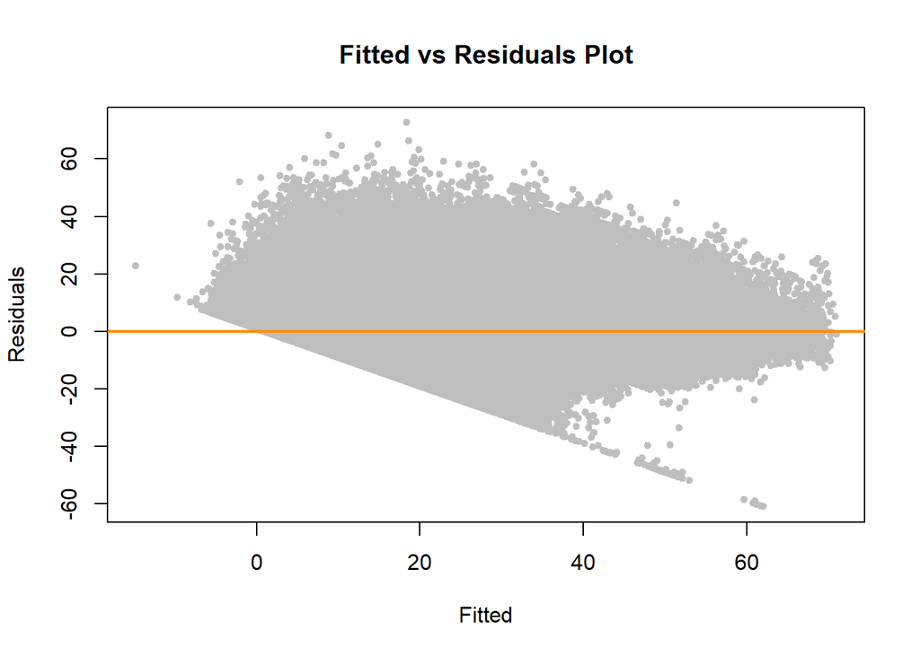

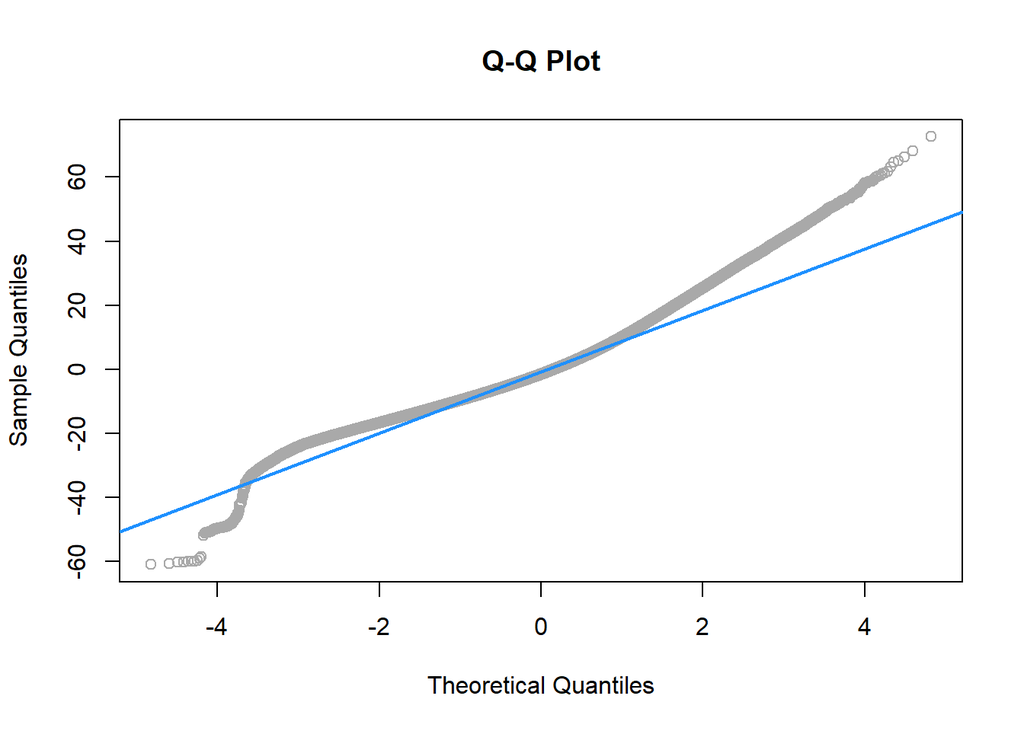

```r
plot_model(model_add_full)
```

We need to adjust our model further. As we suspected before, using transformations and avoiding collinear predictors is necessary.